# Exploratory Data Analysis

## Step 0: Load the Data and Check a few things.

Loading the data for red and white wines separately:

```r
knitr::opts_chunk$set(error = TRUE)
red <- read.csv("./winequality-red.csv")
white <- read.csv("./winequality-white.csv")
```

Labeling the data

```r
red$label <- rep("red", nrow(red))
white$label <- rep("white", nrow(white))
total <- rbind(red, white)
total <- na.omit(total)
```

How are the qualities for the wines (our response variable) distributed?

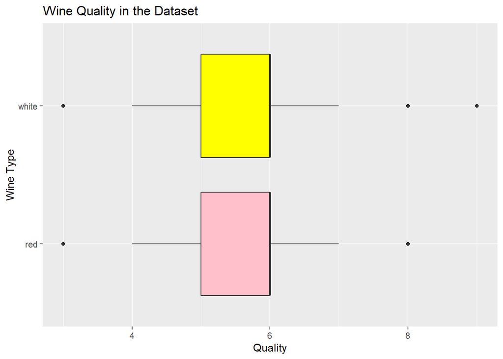

```r
library(ggplot2)

quality_plot <- ggplot(total, aes(quality, label))
quality_plot + geom_boxplot(fill = c('pink', 'yellow')) + ggtitle("Wine Quality in the Dataset")+
xlab('Quality') + ylab('Wine Type')
```

## Step 1: Clustering the Wines

Why treat the two kinds of wine differently? Are red and white wines that different?

Perform k-means here:

```r
library(plyr)
```

```r
library(ggplot2)
library(cluster)
library(lattice)
library(graphics)
library(grid)
library(gridExtra)


kmdata <- as.matrix(total[c("fixed.acidity", "volatile.acidity", "citric.acid",
"residual.sugar", "chlorides", "free.sulfur.dioxide", "total.sulfur.dioxide", "density",
"pH", "sulphates", "alcohol")])


#wss <- numeric(15)
#for (k in 1:15) wss[k] <- sum(kmeans(kmdata, centers = k, nstart = 25)$withinss)
#plot(1:15, wss, type = 'b', xlab = "Number of Clusters", ylab = "WSS")


km <- kmeans(kmdata, 2, nstart = 25)
```

Prepare for plotting here:

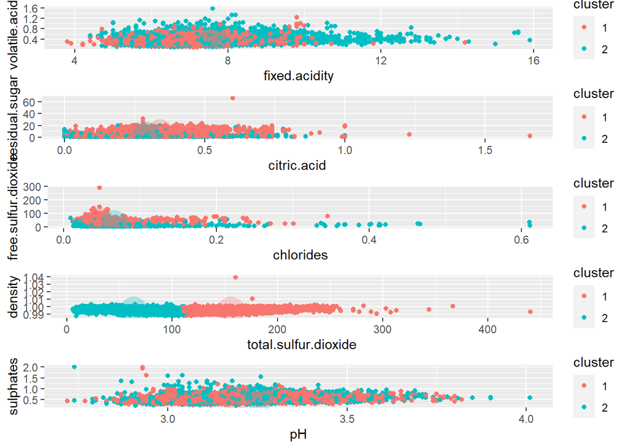

```r
df = as.data.frame(kmdata)
df$cluster = factor(km$cluster)
centers = as.data.frame(km$centers)

g1 <- ggplot(data = df, aes(x = fixed.acidity, y = volatile.acidity, color = cluster)) +
geom_point() + theme(legend.position = "right") +
geom_point(data = centers, aes(x = fixed.acidity, y = volatile.acidity, color = as.factor(c(1,2))), size = 10, alpha = 0.3, show.legend = FALSE)

g2 <- ggplot(data = df, aes(x = citric.acid, y = residual.sugar, color = cluster)) +
geom_point() + theme(legend.position = "right") +
geom_point(data = centers, aes(x = citric.acid, y = residual.sugar, color = as.factor(c(1,2))), size = 10, alpha = 0.3, show.legend = FALSE)

g3 <- ggplot(data = df, aes(x = chlorides, y = free.sulfur.dioxide, color = cluster)) +
geom_point() + theme(legend.position = "right") +
geom_point(data = centers, aes(x = chlorides, y = free.sulfur.dioxide, color = as.factor(c(1,2))), size = 10, alpha = 0.3, show.legend = FALSE)

g4 <- ggplot(data = df, aes(x = total.sulfur.dioxide, y = density, color = cluster)) +
geom_point() + theme(legend.position = "right") +
geom_point(data = centers, aes(x = total.sulfur.dioxide, y = density, color = as.factor(c(1,2))), size = 10, alpha = 0.3, show.legend = FALSE)

g5 <- ggplot(data = df, aes(x = pH, y = sulphates, color = cluster)) +
geom_point() + theme(legend.position = "right") +
geom_point(data = centers, aes(x = pH, y = sulphates, color = as.factor(c(1,2))), size = 10, alpha = 0.3, show.legend = FALSE)

grid.arrange(g1, g2, g3, g4, g5, nrow = 5)
```

Due to the high-dimensionality of the data, the clusters aren’t obvious in the plots except one. Perhaps a Principal Components Analysis can reveal more differences between the two wines…

## Step 2: Principal Components Analysis

```r
pca_red <- prcomp(red[,c("fixed.acidity", "volatile.acidity", "citric.acid",
"residual.sugar", "chlorides", "free.sulfur.dioxide", "total.sulfur.dioxide", "density",
"pH", "sulphates", "alcohol")], scale. = TRUE, center = TRUE)

pca_white <- prcomp(white[,c("fixed.acidity", "volatile.acidity", "citric.acid",
"residual.sugar", "chlorides", "free.sulfur.dioxide", "total.sulfur.dioxide", "density",
"pH", "sulphates", "alcohol")], scale. = TRUE, center = TRUE)
```

The first two PCAs in both the red wine and the white wine datasets don’t explain much of the variance:

```r
summary(pca_red)
```

```
## Importance of components:
##                           PC1    PC2    PC3    PC4     PC5     PC6     PC7
## Standard deviation     1.7604 1.3878 1.2452 1.1015 0.97943 0.81216 0.76406
## Proportion of Variance 0.2817 0.1751 0.1410 0.1103 0.08721 0.05996 0.05307
## Cumulative Proportion  0.2817 0.4568 0.5978 0.7081 0.79528 0.85525 0.90832
##                            PC8     PC9    PC10    PC11
## Standard deviation     0.65035 0.58706 0.42583 0.24405
## Proportion of Variance 0.03845 0.03133 0.01648 0.00541
## Cumulative Proportion  0.94677 0.97810 0.99459 1.00000
```

```r
summary(pca_white)
```

```
## Importance of components:
##                           PC1    PC2    PC3     PC4     PC5     PC6     PC7
## Standard deviation     1.7951 1.2551 1.1053 1.00922 0.98658 0.96889 0.85241
## Proportion of Variance 0.2929 0.1432 0.1111 0.09259 0.08848 0.08534 0.06605
## Cumulative Proportion  0.2929 0.4361 0.5472 0.63979 0.72827 0.81361 0.87967
##                            PC8     PC9    PC10    PC11
## Standard deviation     0.77418 0.64354 0.53804 0.14370
## Proportion of Variance 0.05449 0.03765 0.02632 0.00188
## Cumulative Proportion  0.93416 0.97181 0.99812 1.00000
```

```r
nrow(total)
```

```
## [1] 6497
```

Plotting the PCAs:

For red wine:

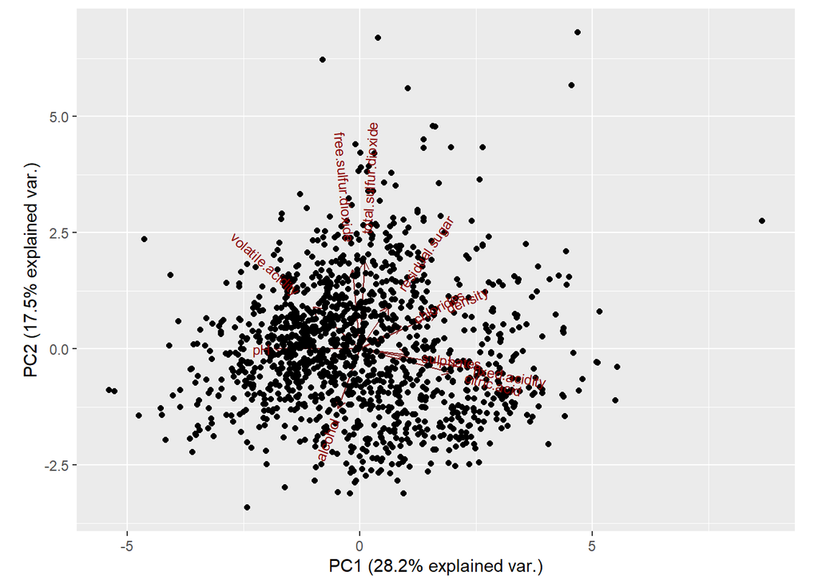

```r
source('https://raw.githubusercontent.com/vqv/ggbiplot/master/R/ggbiplot.r')

source('https://raw.githubusercontent.com/vqv/ggbiplot/master/R/ggscreeplot.r')

ggbiplot(pca_red, obs.scale = 1, var.scale = 1) +
scale_color_discrete(name = '')+
theme(legend.direction = 'horizontal', legend.position = 'top')
```

And for white wine:

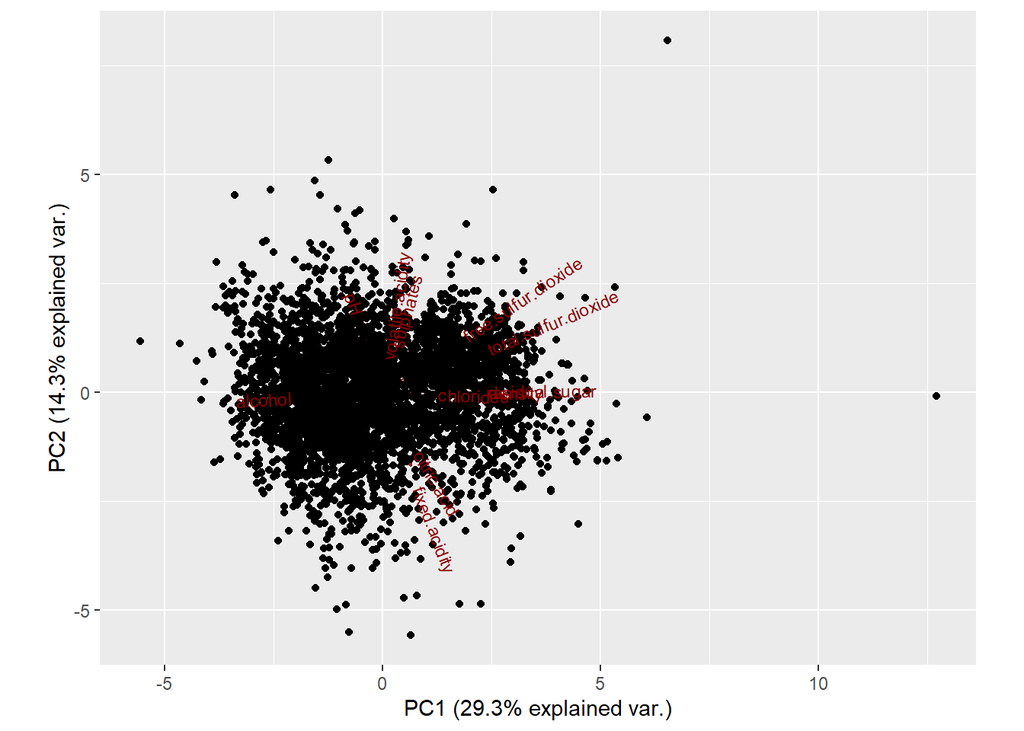

```r
ggbiplot(pca_white, obs.scale = 1, var.scale = 1) +
scale_color_discrete(name = '') +
theme(legend.direction = 'horizontal', legend.position = 'top')
```

Let’s see if there is any difference for both wines plotted together.

PC1 vs. PC2 distinguishes between the two wines:

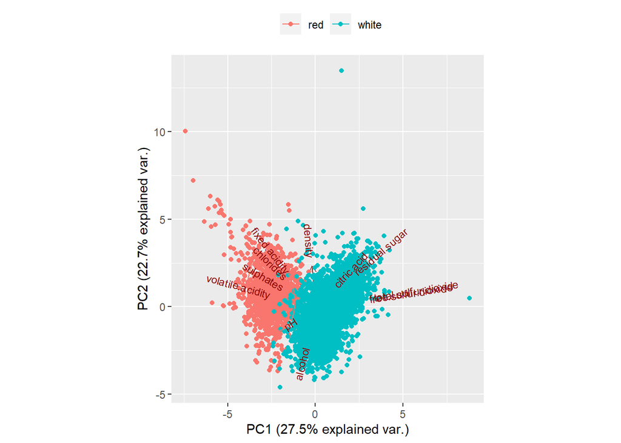

```r
pca_total <- prcomp(total[,c(1:11)], scale. = TRUE, center = TRUE)

ggbiplot(pca_total, obs.scale = 1, var.scale = 1, groups = total$label, ellipse = TRUE) +
scale_color_discrete(name = '') +
theme(legend.direction = 'horizontal', legend.position = 'top')
```

PC1 vs. PC3:

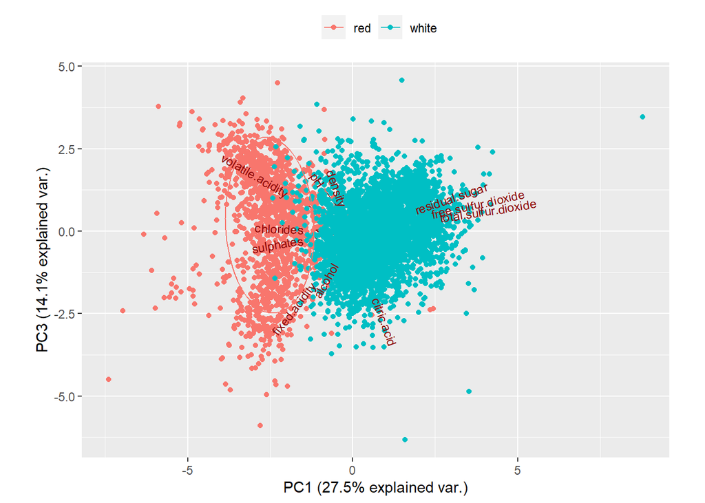

```r
ggbiplot(pca_total, obs.scale = 1, var.scale = 1, choices = c(1,3), groups = total$label, ellipse = TRUE) +
scale_color_discrete(name = '') +
theme(legend.direction = 'horizontal', legend.position = 'top')
```

PC1 vs. PC4:

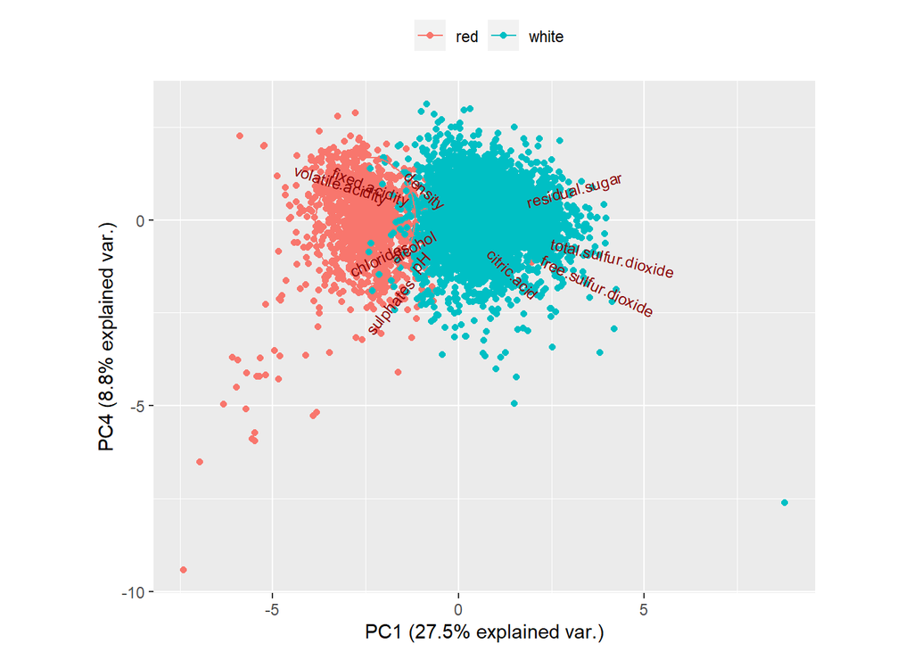

```r
ggbiplot(pca_total, obs.scale = 1, var.scale = 1, choices = c(1,4), groups = total$label, ellipse = TRUE) +
scale_color_discrete(name = '') +
theme(legend.direction = 'horizontal', legend.position = 'top')
```

Hmm, the PCA seems to separate the two wines apart. The first few principal components do not explain much of the variance in the data (the first two barely explain more than 50%). This might suggest the predictors are largely uncorrelated with each other. Nevertheless, we can check for correlation and take appropriate measures to make sure our final predictors are as uncorrelated as possible.

## Step 3: Correlation Matrix of the predictors

```r
corr_red <- cor(red[,c(1:11)])
corr_white <- cor(white[, c(1:11)])
```

Correlation graphs/Heat-maps of the predictors for the Red wine dataset:

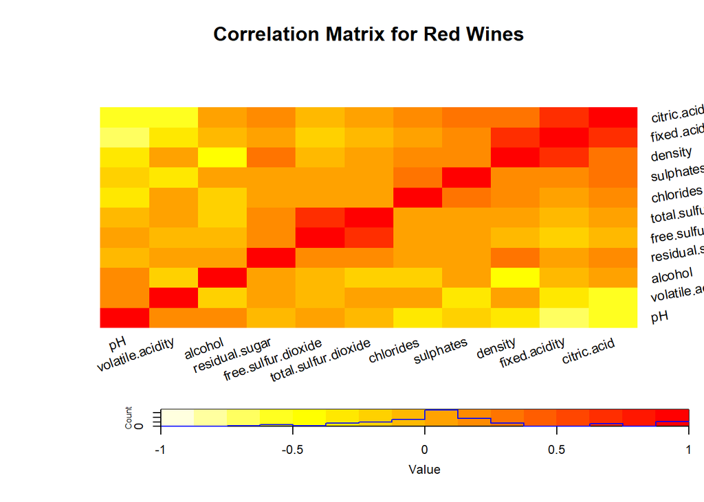

```r
library('gplots')
library('PerformanceAnalytics')
red_map <- heatmap.2(x = corr_red, col = rev(heat.colors(16)), symm = TRUE, dendrogram = 'none',
trace = 'none', main = "Correlation Matrix for Red Wines", key = TRUE,
 lmat=rbind( c(0, 3), c(2,1), c(0,4) ), lhei=c(1.5,4,1.5), lwid = c(0.5,3), srtRow = 10, srtCol = 20, symkey = TRUE, key.title = NA,
 tracecol = 'blue')
```

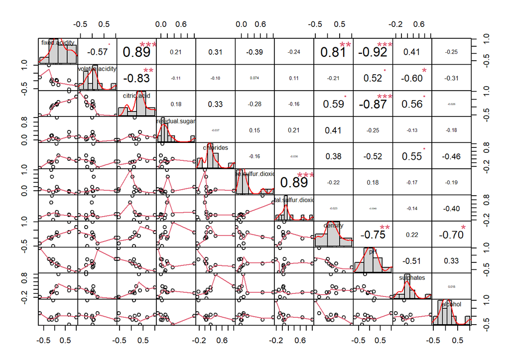

```r
chart.Correlation(corr_red, histogram = TRUE, pch = 1)
```

And for White wines:

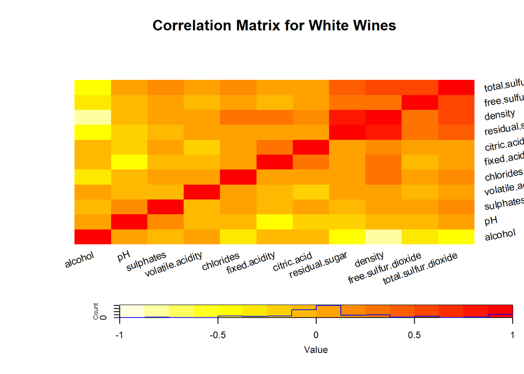

```r
white_map <- heatmap.2(x = corr_white, col = rev(heat.colors(16)), symm = TRUE, dendrogram = 'none',
trace = 'none', main = "Correlation Matrix for White Wines", key = TRUE,
 lmat=rbind( c(0, 3), c(2,1), c(0,4) ), lhei=c(1.5,4,1.5), lwid = c(0.5,3), srtRow = 10, srtCol = 20, symkey = TRUE, key.title = NA,
 tracecol = 'blue')
```

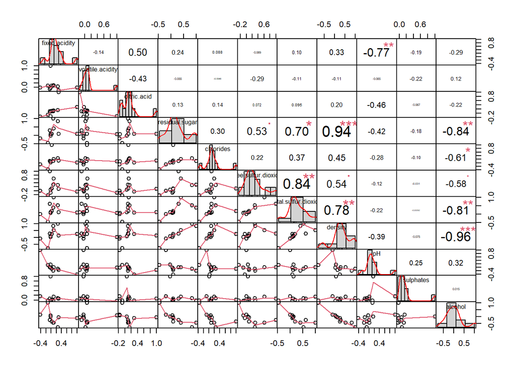

```r
chart.Correlation(corr_white, histogram = TRUE, pch = 1)
```

Some predictors are highly correlated in both datasets (>50%). Moreover, some of them are not the same pairs across both datasets.

## New Scatterplots with the correlated variables removed.

```r
corr_red_new <-cor(red[,c("citric.acid",
"residual.sugar", "chlorides", "free.sulfur.dioxide", "sulphates", "alcohol")])

corr_white_new <- cor(white[, c("fixed.acidity", "volatile.acidity", "citric.acid",
"residual.sugar", "chlorides", "free.sulfur.dioxide", "sulphates")])
```

For red wine (new)

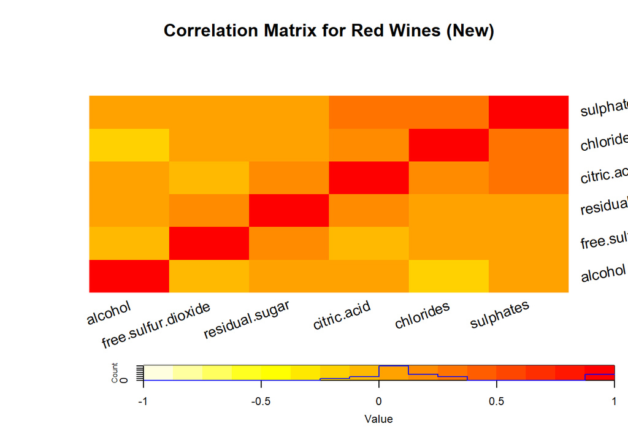

```r
red_map_new <- heatmap.2(x = corr_red_new, col = rev(heat.colors(16)), symm = TRUE, dendrogram = 'none',
trace = 'none', main = "Correlation Matrix for Red Wines (New)", key = TRUE,
 lmat=rbind( c(0, 3), c(2,1), c(0,4) ), lhei=c(1.5,4,1.5), lwid = c(0.5,3), srtRow = 10, srtCol = 20, symkey = TRUE, key.title = NA,
 tracecol = 'blue')
```

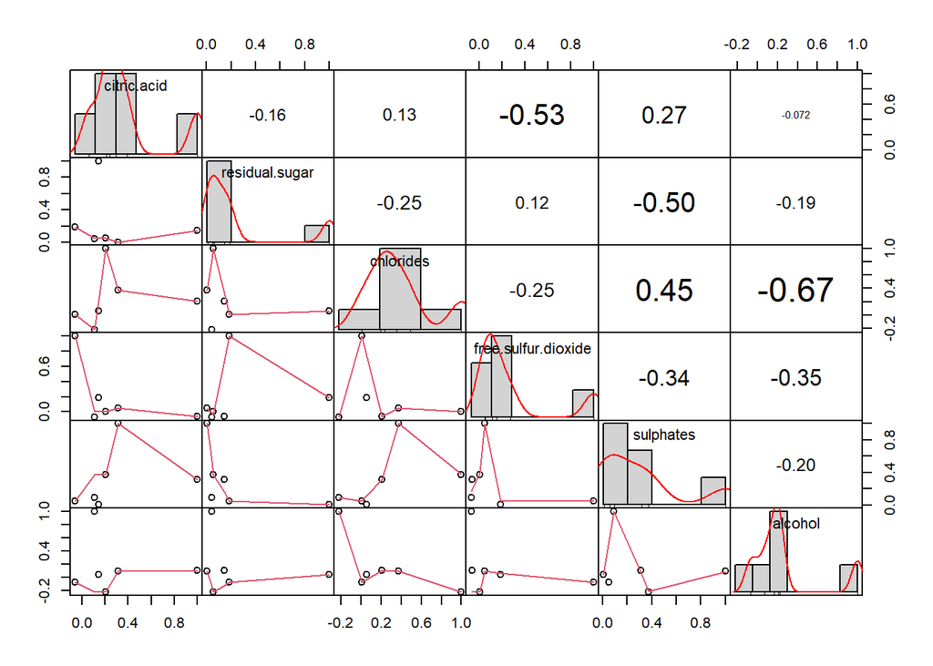

```r
chart.Correlation(corr_red_new, histogram = TRUE, pch = 1)
```

For white wine (new)

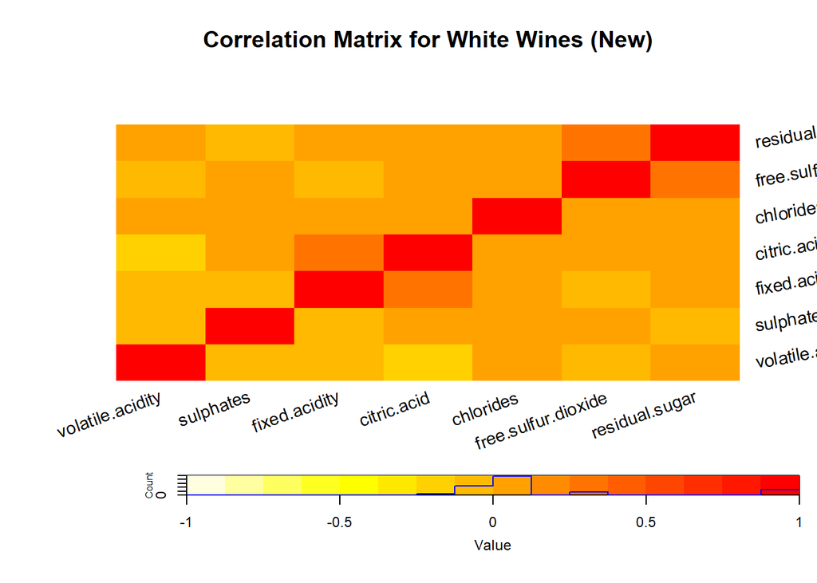

```r
white_map_new <- heatmap.2(x = corr_white_new, col = rev(heat.colors(16)), symm = TRUE, dendrogram = 'none',
trace = 'none', main = "Correlation Matrix for White Wines (New)", key = TRUE,
 lmat=rbind( c(0, 3), c(2,1), c(0,4) ), lhei=c(1.5,4,1.5), lwid = c(0.5,3), srtRow = 10, srtCol = 20, symkey = TRUE, key.title = NA,
 tracecol = 'blue')
```

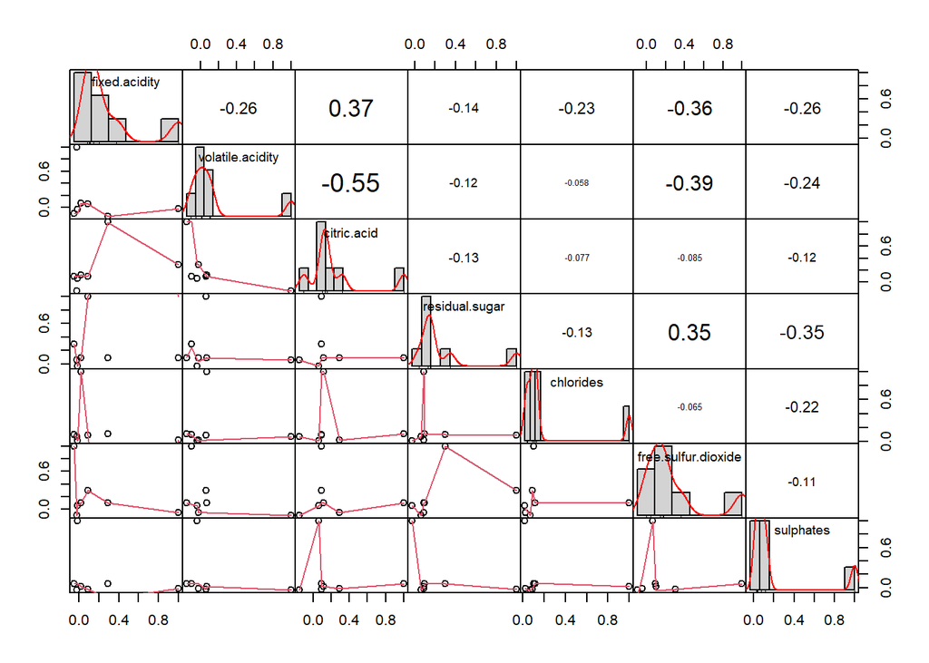

```r
chart.Correlation(corr_white_new, histogram = TRUE, pch = 1)
```